# assignment4_task2_gb

Gabrielle Barsotti

11/13/2020

## Introduction

This report provides an exploratory overview of differences in juvenile Snowshoe Hare observations by count, weight and hind foot length. These observations were taken from three different locations (Black Spruce, Mature, and Riparian) within the Bonanza Creek Long Term Ecological Reserve (LTER) Experimental Forest in Fairbanks, Alaska from 1999-2012 (Kielland et al. (2017)). The document will compare first juvenile hare per year, then juveniles by sex over three locations and finally the relationship between juvenile weight and hind foot length.

## Data & Analysis

Snowshoe Hare physical data was collected and made available by Dr. Kielland and colleagues at Bonanza Creek (LTER) Experimental Forest in Fairbanks, Alaska. The data contained 3,197 individual hare observations across three locations in the Tanana valley from 1999-2012 (Kielland et al.(2017)). After exploring the data through data visualization, weights between male and female hares are compared using a two-sample t-test with a significance level ($\alpha$) of 0.05 throughout. Cohen’s *d* effect size is used to describe the differences between these male and female juvenile hare groups. Simple linear regression is used to explore the relationship between between weight and hind foot length. All analyses are in R version 4.0.2 using RStudio version 1.3.1056.

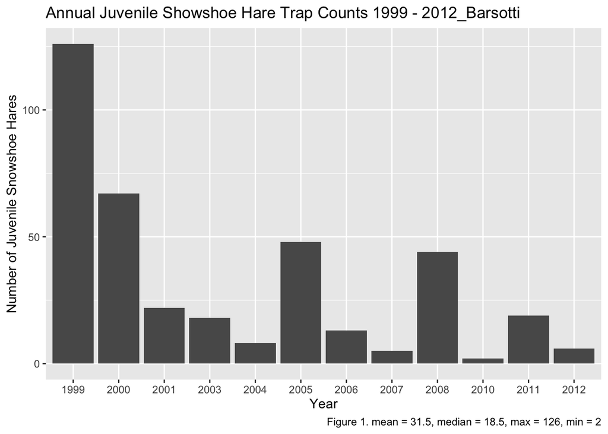

## Description

The graph of juvenile snowshoe hares trapped from 1999 - 2012 shows a declining trend in the number of hares trapped per year. This trending decline shows that a standardization of data collection methods need to be put in place for further analysis in future years. This standardization can be done if the same number of traps are set up and the same number of trapping days are completed each year. Since juvenile hares grow so quickly then trapping could be done at more frequently. Traps will also need to be placed that the same locations and times to keep up with consistency and accuracy in the data. There were two years missing in the data set that show no traps were places and this can skew the data in a certain direction if not properly addressed.

## Part 2

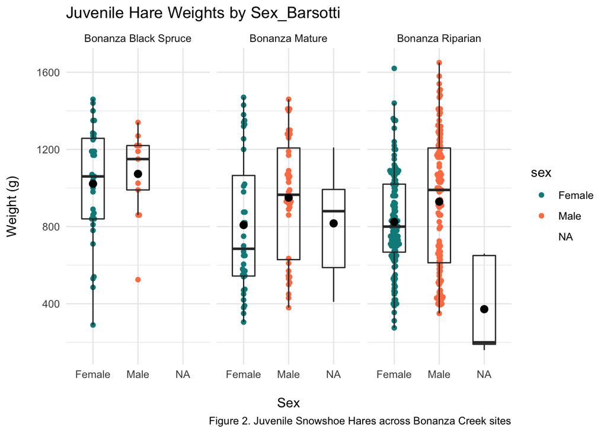

**Figure 2.** Juvenile Snowshoe Hare weight (grams) observations across three Bonanza Creek sites (Black Spruce, Mature, and Riparian). Teal (Female), Orange (Male) points indicate individual observations for weight of juvenile hares. Box endpoints indicate the 25th<sup>th</sup> and 75<sup>th</sup> percentile values; the black line point within the box indicate the median and mean values for each sex, respectively. Data: Kielland et al.(2017)

### iii) Further Explantation of Juvenile weights

**Table 1.** Descriptive statistics(mean, standard deviation of all three Bonaza Creek sites (Black Spruce, Mature and Riparian). Data: Kielland et al. (2017)

| Sex | Mean weight (g) | Standard deviation (mm) | Sample size |
| --- | --- | --- | --- |
| Female | 855.39 | 292.25 | 197 |
| Male | 945.86 | 333.22 | 163 |

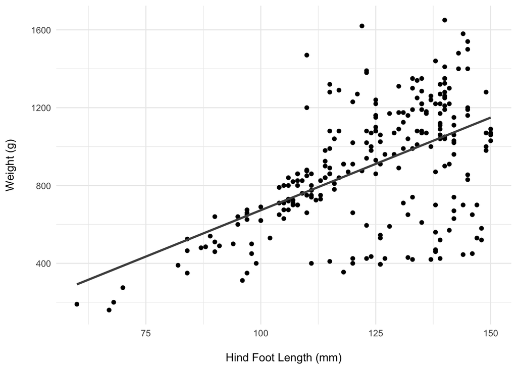

**Figure 3.** Relationship between weight (g) and hind foot length (mm) in juvenile hares. The points indicate individual juvenile hare measurements. Linear model summary: $\beta$<sub>1</sub> = 9.52 g mm<sup>-1</sup>, p < 0.001, R<sup>2</sup> = 0.3, Pearson’s *r* = 0.55). Data: Kielland et al. (2017).

## Description of Relationship between juvenile weight & hind foot length

The relationship between juvenile hare weight and hind foot length is showing a positive trend, as weight increase then hind foot length increases.

## Summary

### Citations

Kielland, K., F.S. Chapin, R.W. Ruess, and Bonanza Creek LTER, 2017, Snowshoe hare physical data in Bonanza Creek Experimental Forest: 1999-Present ver 22. Environmental Data Initiative, https://doi.org/10.6073/pasta/03dce4856d79b91557d8e6ce2cbcdc14